# Recommending movies from around the world!

### Allison King

### May 3rd, 2017

## Motivation

One of the potential dangers in recommender systems is also what they are meant to do- recommend you things that you will continue to like. This can lead people to continue liking things they already like with nothing that would inspire them to try something out of their comfort zone. Branching out can lead to diversity in thinking as well as increased empathy. Therefore, the goal of this project is to deliberately use a user's preference to recommend them movies from another country. The user will be able to choose a country, then the recommender will use their preferences to recommend a movie for them from that country. This project was partly inspired by [Book Riot's list of 80 books from the 80 most populated countries in the world](http://bookriot.com/2016/04/28/around-world-80-books-global-reading-list/).

## Getting the data we need

We'll begin by importing some data. We're going to use the [Movielens](https://grouplens.org/datasets/movielens/) dataset, a dataset of user ratings of movies collected by GroupLens Research at the Department of Computer Science and Engineering at the University of Minnesota.

This dataset comes with the following files:

- `links.csv`: a list of movie ids, along with their IMDB ids.
- `movies.csv`: a list of movie ids, their title, and their genre
- `ratings.csv`: a list of user ids, the movie id of the movie they rated, the rating they gave it, and the timestamp of when they rated the movie
- `tags.csv`: a list of user created tags

Unfortunately, the Movielens data doesn't automatically come with the country associated with each movie. That's okay though- we can write some scripts to grab that data for us. We can do this data gathering using [OMDB](http://www.omdbapi.com/), the Open Movie database, whose API allows us to access IMDB data. Luckily, thanks to `links.csv`, we have the IMDB ids, so accessing the data is easy.

In the code snippet below, we can see the first five rows of `links.csv`. We'll be using [pandas](http://pandas.pydata.org/), a data analysis library, for most of our data manipulation... at first.

## Using the MovieLens data

```python
# pandas library for data analysis (good for reading in and manipulating our CSV files)
import pandas as pd
# we'll need the requests library to make http requests to the OMDB API
import requests

# open links.csv in order to access IMDB id numbers
links_file = pd.read_csv('movie-lens-data/links.csv', dtype={'imdbId': object, 'tmdbId': object})
links_file.head(n=5)
```

|  | movieId | imdbId | tmdbId |
| --- | --- | --- | --- |
| 0 | 1 | 0114709 | 862 |
| 1 | 2 | 0113497 | 8844 |
| 2 | 3 | 0113228 | 15602 |
| 3 | 4 | 0114885 | 31357 |
| 4 | 5 | 0113041 | 11862 |

## Getting data that we'll need

We'll do one example of using the `requests` library to get our data from OMDB next.

```python
# get the OMDB API URL
omdb_url = 'http://www.omdbapi.com/?i=tt'

# get the IMDB id for one of our movies
imdb_id = links_file.iloc[0].imdbId

# get the full OMDB url
url = omdb_url + imdb_id
print 'The OMDB URL we will send our request to: %s' % url

# get the countries associated with the movie
response = requests.get(url)
countries = response.json()['Country']
print 'Country associated with movieId %s: %s' %(links_file.iloc[0].movieId, countries)
```

```
The OMDB URL we will send our request to: http://www.omdbapi.com/?i=tt0114709
Country associated with movieId 1: USA
```

Cool, so we found the first movie listed was a movie from the USA! So what movie was it? Since we only have the movie ID, we'll have to JOIN it with the information in `movies.csv` to get the actual movie title.

```python
movies_file = pd.read_csv('movie-lens-data/movies.csv')
movies_file.head(n=5)
```

|  | movieId | title | genres |
| --- | --- | --- | --- |
| 0 | 1 | Toy Story (1995) | Adventure\|Animation\|Children\|Comedy\|Fantasy |
| 1 | 2 | Jumanji (1995) | Adventure\|Children\|Fantasy |
| 2 | 3 | Grumpier Old Men (1995) | Comedy\|Romance |
| 3 | 4 | Waiting to Exhale (1995) | Comedy\|Drama\|Romance |
| 4 | 5 | Father of the Bride Part II (1995) | Comedy |

Oh cool- Toy Story, most definitely a movie from the US! We can add this to our `movies.csv` file so that it will look like:

```python
movies_file.set_value(0, 'country', countries)
movies_file.head(n=5)
```

|  | movieId | title | genres | country |
| --- | --- | --- | --- | --- |
| 0 | 1 | Toy Story (1995) | Adventure\|Animation\|Children\|Comedy\|Fantasy | USA |
| 1 | 2 | Jumanji (1995) | Adventure\|Children\|Fantasy | NaN |
| 2 | 3 | Grumpier Old Men (1995) | Comedy\|Romance | NaN |
| 3 | 4 | Waiting to Exhale (1995) | Comedy\|Drama\|Romance | NaN |
| 4 | 5 | Father of the Bride Part II (1995) | Comedy | NaN |

We'll do this for the entire `movies.csv` file. Once we do that, we can take a look at our data.

## Examining the Movielens dataset

Since we're recommending movies by country, we should get a sense of how our data is distributed across countries. I went through the data and got some stats on the countries. Some movies have multiple countries associated with them, marked by 'USA|China|UK', for example, so in these cases I counted the movie as one for each of those countries.

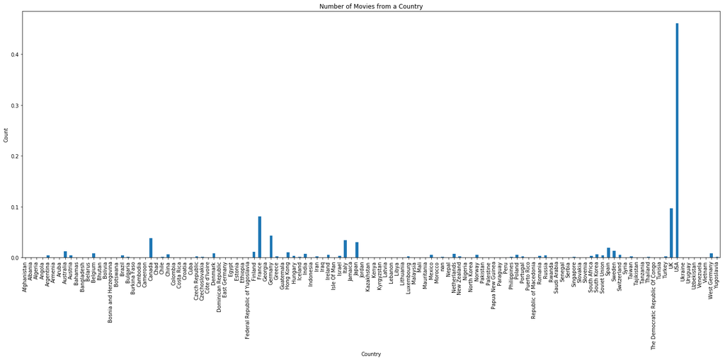

```python
# stuff to make our graph show up in the notebook
%matplotlib inline
import matplotlib
import matplotlib.pyplot as plt
matplotlib.rcParams['figure.figsize'] = (20.0, 10.0)

# read in the file I had generated of number of times a country is attributed to a movie
country_stats = pd.read_csv('scripts/output/country-stats-20m.csv')
axes = country_stats.plot(x='country', y='count_percentage', kind='bar', title='Number of Movies from a Country',
                              legend=False)
# set the axes and set display
axes.set_xlabel("Country")
axes.set_ylabel("Count")
plt.tight_layout()
plt.show()
```

## Recommender Types

We're going to try out three different types of recommendation systems:

- Popularity Recommender
- Item Similarity Recommender
- Ranking Factorization Recommender

The following code involves importing the data and splitting it into test and train data. This code will be used for all of the recommender types.

## Some general code every recommender system needs

```python
# let's choose a country that we're interested in watching a movie from
country = 'Japan'

# we'll import the ratings.csv which has data in the format of userId, movieId, rating, timestamp
ratings_csv_path = 'movie-lens-data/ratings.csv'
ratings_data = pd.read_csv(ratings_csv_path, encoding='utf-8')
ratings_data.head(n=5)
```

|  | userId | movieId | rating | timestamp |
| --- | --- | --- | --- | --- |
| 0 | 1 | 31 | 2.5 | 1260759144 |
| 1 | 1 | 1029 | 3.0 | 1260759179 |
| 2 | 1 | 1061 | 3.0 | 1260759182 |
| 3 | 1 | 1129 | 2.0 | 1260759185 |
| 4 | 1 | 1172 | 4.0 | 1260759205 |

Here's the output of the script from earlier that fetched all of our country data for us.

```python
# now we need a data frame of the data we just got from OMDB that includes the country data
# this file is of the format movieId, title, genres, country
movies_country_csv_path = 'scripts/output/movie-countries.csv'
movies_data = pd.read_csv(movies_country_csv_path, encoding='utf-8', keep_default_na=False)
movies_data.head(n=5)
```

|  | movieId | title | genres | country |
| --- | --- | --- | --- | --- |
| 0 | 1 | Toy Story (1995) | Adventure\|Animation\|Children\|Comedy\|Fantasy | USA |
| 1 | 2 | Jumanji (1995) | Adventure\|Children\|Fantasy | USA |
| 2 | 3 | Grumpier Old Men (1995) | Comedy\|Romance | USA |
| 3 | 4 | Waiting to Exhale (1995) | Comedy\|Drama\|Romance | USA |
| 4 | 5 | Father of the Bride Part II (1995) | Comedy | USA |

Now that we have our data, we want to split it into training and test data.

```python
from sklearn.model_selection import train_test_split

# split 80% training, 20% testing
training_data, test_data = train_test_split(ratings_data, test_size=0.2, random_state=8)
print "number of ratings in training set: %d " % training_data.shape[0]
print "number of ratings in test set: %d " % test_data.shape[0]
```

```
number of ratings in training set: 80003
number of ratings in test set: 20001
```

Alright, now we're ready for each recommender type!

## Merge our ratings data with our movie/country data

```python
training_ratings_with_movies = pd.merge(training_data, movies_data, on='movieId').sort_values(by=['userId', 'movieId'])
training_ratings_with_movies.head(n=5)
```

|  | userId | movieId | rating | timestamp | title | genres | country |
| --- | --- | --- | --- | --- | --- | --- | --- |
| 37471 | 1 | 31 | 2.5 | 1260759144 | Dangerous Minds (1995) | Drama | USA |
| 51485 | 1 | 1029 | 3.0 | 1260759179 | Dumbo (1941) | Animation\|Children\|Drama\|Musical | USA |
| 65861 | 1 | 1061 | 3.0 | 1260759182 | Sleepers (1996) | Thriller | USA |
| 2211 | 1 | 1129 | 2.0 | 1260759185 | Escape from New York (1981) | Action\|Adventure\|Sci-Fi\|Thriller | UK\|USA |
| 48757 | 1 | 1263 | 2.0 | 1260759151 | Deer Hunter, The (1978) | Drama\|War | USA |

## Filter for our country

```python
# now we can apply a filter for country on the data set.
country_filter = training_ratings_with_movies[training_ratings_with_movies.apply(
    lambda x: country in x['country'], axis=1)]
print "total number of movies associated with %s: %d" %(country, country_filter.shape[0])
country_filter.head(n=5)
```

```
total number of movies associated with Japan: 1723
```

|  | userId | movieId | rating | timestamp | title | genres | country |
| --- | --- | --- | --- | --- | --- | --- | --- |
| 13637 | 2 | 273 | 4.0 | 835355779 | Mary Shelley's Frankenstein (Frankenstein) (1994) | Drama\|Horror\|Sci-Fi | USA\|Japan\|UK |
| 66835 | 4 | 4006 | 2.0 | 949982238 | Transformers: The Movie (1986) | Adventure\|Animation\|Children\|Sci-Fi | USA\|Japan |
| 38023 | 5 | 6711 | 2.5 | 1163373238 | Lost in Translation (2003) | Comedy\|Drama\|Romance | USA\|Japan |
| 50827 | 6 | 1687 | 2.0 | 1109258281 | Jackal, The (1997) | Action\|Thriller | USA\|UK\|France\|Germany\|Japan |
| 44508 | 9 | 2391 | 4.0 | 939122916 | Simple Plan, A (1998) | Crime\|Drama\|Thriller | UK\|Germany\|France\|USA\|Japan |

## What makes a movie from a country?

We can do this country filter multiple ways. This first way takes any movie that has Japan associated with it. This next filter only accepts movies where Japan is the sole attributed country. This may be relevant since it seems that many times when a country is attributed as one among many countries, the movie does not actually have much to do with that country. For instance, A Simple Plan was co-financed by international partners from Germany, UK, France and so have these countries attributed to it. This isn't ideal if our goal is to learn about Japan as a country, so the sole filter may be more useful.

## Filter for movies associated *only* with our country

```python
sole_country_filter = training_ratings_with_movies.loc[training_ratings_with_movies['country']==country]
print "total number of movies attributed solely to %s: %d" %(country, sole_country_filter.shape[0])
sole_country_filter.head(n=5)
```

```
total number of movies attributed solely to Japan: 659
```

|  | userId | movieId | rating | timestamp | title | genres | country |
| --- | --- | --- | --- | --- | --- | --- | --- |
| 65974 | 12 | 3799 | 1.0 | 968045198 | Pokémon the Movie 2000 (2000) | Animation\|Children | Japan |
| 78427 | 12 | 3864 | 3.0 | 968045015 | Godzilla 2000 (Gojira ni-sen mireniamu) (1999) | Action\|Adventure\|Sci-Fi | Japan |
| 64050 | 15 | 2905 | 4.0 | 1040205754 | Sanjuro (Tsubaki Sanjûrô) (1962) | Action\|Adventure\|Drama | Japan |
| 8983 | 15 | 3000 | 4.0 | 997939086 | Princess Mononoke (Mononoke-hime) (1997) | Action\|Adventure\|Animation\|Drama\|Fantasy | Japan |
| 61210 | 15 | 3030 | 4.0 | 997939021 | Yojimbo (1961) | Action\|Adventure | Japan |

Okay, now the fun part- let's see what the most popular movies are from Japan.

```python
import numpy as np

popular_movies = sole_country_filter.groupby('title').agg({'rating': [np.size, np.mean]}).sort_values(
    [('rating', 'mean')], ascending=False).reset_index()
popular_movies.head(n=5)
```

|  | title | rating size | rating mean |
| --- | --- | --- | --- |
| 0 | Maborosi (Maboroshi no hikari) (1995) | 1.0 | 5.0 |
| 1 | Ghost in the Shell 2.0 (2008) | 1.0 | 5.0 |
| 2 | Wolf Children (Okami kodomo no ame to yuki) (2... | 1.0 | 5.0 |
| 3 | Wild Zero (2000) | 1.0 | 5.0 |
| 4 | One Piece Film: Strong World (2009) | 1.0 | 5.0 |

This isn't ideal- these movies that have only one rating are getting really high ratings since one person gave them a five star. That's hardly what popular means! We could apply some sort of algorithm in order to get a better 'popularity' score. The function below is adapted from [Evan Miller's post](http://www.evanmiller.org/how-not-to-sort-by-average-rating.html) on how to get a more accurate rating.

### Wilson Score Example

```python
from math import sqrt

def wilson_score(num_positive_ratings, num_ratings):
    # we'll default to a 95% confidence level
    if num_ratings == 0:
        return 0
    # this is a z score, since we're using a 95% confidence level, z will always be 1.96
    z = 1.96
    phat = 1.0 * num_positive_ratings / num_ratings
    return (phat + z*z/(2*num_ratings) - z *
            sqrt((phat*(1-phat)+z*z/(4*num_ratings))/num_ratings))/(1+z*z/num_ratings)

wilson_score(80, 100)
```

```
0.7111690380734976
```

### Applying Wilson Score to our dataset

```python
# here's a function to help us determine what a 'positive' rating is
def number_positive_ratings(x):
    pos = x[x >= 3]
    return pos.size

# make our data frame show us the number of positive ratings, as well as number overall ratings
# grouped by movie title
grouped_ratings = sole_country_filter.groupby('title').agg({
        'rating': [number_positive_ratings, np.size]}).reset_index()

# apply the wilson score function now that we have number of positive ratings and number of overall ratings
grouped_ratings['wilson score'] = np.vectorize(wilson_score)(grouped_ratings['rating']['number_positive_ratings'],
                                                             grouped_ratings['rating']['size'])

# let's see what's popular in Japan!
grouped_ratings[['title','wilson score']].sort_values('wilson score', ascending=False).head(n=5)
```

|  | title | wilson score |
| --- | --- | --- |
| 127 | Seven Samurai (Shichinin no samurai) (1954) | 0.834958 |
| 131 | Spirited Away (Sen to Chihiro no kamikakushi) ... | 0.790215 |
| 113 | Princess Mononoke (Mononoke-hime) (1997) | 0.786762 |
| 55 | Ghost in the Shell (Kôkaku kidôtai) (1995) | 0.773302 |
| 114 | Rashomon (Rashômon) (1950) | 0.771898 |

Nice- this list of movies looks a lot more reasonable. The Wilson Score tells us how confident we are that ratings for this movie is positive. Even I, an ignorant American, have heard of most of these movies before. I had never heard of Seven Samurai, but the [Seven Samurai Wikipedia](https://en.wikipedia.org/wiki/Seven_Samurai) page says:

> Since its release, Seven Samurai has consistently ranked highly in critics' lists of the greatest films, such as the BFI's Sight & Sound and Rotten Tomatoes polls. It has remained highly influential, often seen as one of the most "remade, reworked, referenced" films in cinema.

A search of Rashomon on Wikipedia says:

> Rashomon marked the entrance of Japanese film onto the world stage; it won several awards, including the Golden Lion at the Venice Film Festival in 1951, and an Academy Honorary Award at the 24th Academy Awards in 1952, and is now considered one of the greatest films ever made.

So it seems like we are indeed getting popular movies back!

### Item Similarity Recommender

Alright, let's move on and try to get some personalization with our recommendations. The next method we are going to use is the Item Similarity Recommender. What this means is that you tell the model the movies you like, and the model will go and try to find the movies that are the most similar to the ones that you liked and return them to you.

To create the model, we take in our user ratings file. The model will compute the similarity between movies by associating movies that a user has watched before and enjoyed as similar. The similarity function is often a Cosine or Pearson similarity function.

[Ethan Rosenthal's blog post](http://blog.ethanrosenthal.com/2015/11/02/intro-to-collaborative-filtering/) was very helpful in this effort.

## Building a user-item matrix

The idea behind a user-item matrix is that we have users along the rows, and items along the columns. We can fill in the matrix with all of our known ratings, and from there we want to be able to fill in (or predict) our missing ratings.

```python
# we'll need some more helper functions
from sklearn.metrics.pairwise import pairwise_distances
from sklearn.metrics import mean_squared_error

num_users = ratings_data.userId.unique().shape[0]
num_movies = ratings_data.movieId.unique().shape[0]
print "Number of unique users: %d" % num_users
print "Number of unique movies: %d" %num_movies
```

```
Number of unique users: 671
Number of unique movies: 9066
```

Our matrix is going to be dimension num_users x num_movies. While userId goes from 1 to num_users, the range of num_movies is actually very large, as there are thousands of movies in the Movielens dataset, but since they only included data for users who rated over 20 movies, and because this is their smaller dataset, there are a lot of missing movieIds. So ideally we want a map that goes from 1 to num_movies, where each index maps to a movieId. In other words, if there were only two movies in our dataset with movieIds 1 and 999,999, we only want our matrix to be num_users x 2, not num_users x 999,999.

```python
# function to make a movie map out of our list of movies
def get_index_movie_map(data):
    movie_map = {}
    no_duplicates = data.movieId.unique()
    index = 0
    for movieId in no_duplicates:
        movie_map[movieId] = index
        index = index + 1

    return movie_map

movie_map = get_index_movie_map(ratings_data)
print "Index 1 maps to movieId %d in movie_map" % movie_map[1]
print "Index 2 maps to movieId %d in movie_map" % movie_map[2]
```

```
Index 1 maps to movieId 417 in movie_map
Index 2 maps to movieId 650 in movie_map
```

Nice- now we can make our num_users by num_movies matrix.

```python
# function to create the user-item matrix
def get_user_item_matrix(n_users, n_items, data, movie_map):
    """Returns the user item matrix for a given set of data"""
    matrix = np.zeros((n_users, n_items))
    for line in data.itertuples():
        matrix[line[1]-1, movie_map[line[2]]] = line[3]

    return matrix

# matrix for training data
train_data_matrix = get_user_item_matrix(num_users, num_movies, training_data, movie_map)
# matrix for test data (to use later)
test_data_matrix = get_user_item_matrix(num_users, num_movies, test_data, movie_map)
print train_data_matrix.shape
train_data_matrix[:10, :10]
```

```
(671, 9066)
```

```
array([[ 2.5,  3. ,  3. ,  2. ,  0. ,  2. ,  2. ,  2. ,  3.5,  2. ],
       [ 0. ,  0. ,  0. ,  0. ,  0. ,  0. ,  0. ,  0. ,  0. ,  0. ],
       [ 0. ,  0. ,  0. ,  0. ,  0. ,  0. ,  0. ,  0. ,  0. ,  0. ],
       [ 0. ,  0. ,  0. ,  0. ,  0. ,  0. ,  0. ,  0. ,  0. ,  0. ],
       [ 0. ,  0. ,  0. ,  0. ,  0. ,  0. ,  0. ,  0. ,  0. ,  0. ],
       [ 0. ,  0. ,  0. ,  0. ,  0. ,  0. ,  0. ,  0. ,  0. ,  0. ],
       [ 0. ,  0. ,  0. ,  0. ,  0. ,  0. ,  4. ,  0. ,  0. ,  0. ],
       [ 0. ,  0. ,  0. ,  0. ,  0. ,  0. ,  0. ,  0. ,  0. ,  0. ],
       [ 0. ,  0. ,  0. ,  0. ,  0. ,  0. ,  0. ,  0. ,  0. ,  0. ],
       [ 0. ,  0. ,  0. ,  0. ,  0. ,  0. ,  0. ,  0. ,  0. ,  0. ]])
```

Along the y axis of this array we have the users, and along the x axis we have the movie. Most of these are zeros, as expected, since there are far more movies than users- any given user has probably only rated a small percentage of the total number of movies. We should also keep in mind that the zeros in the array are not actually a zero rating- they are just an empty rating.

Now we can find our cosine similarities. We can treat each column in the matrix as a vector- how similar two items are is "depedent upon the ratings given to the items by users who have rated both of them"

[figure not shown]

[[1] Carleton CS](http://www.cs.carleton.edu/cs_comps/0607/recommend/recommender/itembased.html)

The equation for cosine similarity:

[figure not shown]

[[2] Cosine similarity wikipedia page](https://en.wikipedia.org/wiki/Cosine_similarity)

We can implement cosine similarity between every column in the matrix as a for loop in Python, but it takes quite a while so instead we'll use [sklearn's pairwise distance function](http://scikit-learn.org/stable/modules/generated/sklearn.metrics.pairwise.pairwise_distances.html).

```python
item_similarity = 1 - pairwise_distances(train_data_matrix.T, metric='cosine')
print item_similarity.shape
item_similarity[:4,:4]
```

```
(9066, 9066)
```

```
array([[ 1.        ,  0.11812984,  0.18786734,  0.13968562],
       [ 0.11812984,  1.        ,  0.14008916,  0.17413503],
       [ 0.18786734,  0.14008916,  1.        ,  0.16159244],
       [ 0.13968562,  0.17413503,  0.16159244,  1.        ]])
```

Time to make predictions! In order to make predictions, we use weighted sums.

[figure not shown]

[[3] Depaul CS](http://facweb.cs.depaul.edu/mobasher/classes/csc575/assignments/knn-predictions.html)

In this formula, the $\sum r(U_i, I_t)$ term is the rating given by user $U$ to item $I$- the sum means it's the sum of all of the similar items. We multiply this term by the similarity to the new user (represented by $NU$) to the user $U$. Then we divide in order to scale the prediction. This formula is basically saying to weigh the new user's rating for each item by its similarity to the target item.

### Prediction matrix

```python
def predict(ratings, similarity):
    prediction = ratings.dot(similarity) / np.array([np.abs(similarity).sum(axis=1)])
    return prediction

item_prediction = predict(train_data_matrix, item_similarity)
print(item_prediction.shape)
item_prediction[:4,:4]
```

```
(671, 9066)
```

```
array([[ 0.02206483,  0.01469837,  0.02130051,  0.01500874],
       [ 0.1156563 ,  0.04677068,  0.0632285 ,  0.04164237],
       [ 0.050136  ,  0.02596775,  0.04007407,  0.02854181],
       [ 0.22425475,  0.19581378,  0.21881686,  0.186501  ]])
```

Wow- we're back to the shape of the matrix we started with (num_users x num_movies) but now we have all of the numbers in the matrix filled in. Now we should test against the test data to see how well we're doing.

### Root mean square error evaluation

```python
def rmse(prediction, ground_truth):
    prediction = prediction[ground_truth.nonzero()].flatten()
    ground_truth = ground_truth[ground_truth.nonzero()].flatten()
    return sqrt(mean_squared_error(prediction, ground_truth))

print "Training data RMSE: %s" % str(rmse(item_prediction, train_data_matrix))
print "Test data RMSE: %s" % str(rmse(item_prediction, test_data_matrix))
```

```
Training data RMSE: 3.22455168723
Test data RMSE: 3.4301654578
```

It seems like our training and test RMSE's are fairly close. It's still hard to say intuitively if that means anything though, so let's look at some actual movies.

```python
# function to get the key from the value in the movie map
def get_movie_id_from_index(search_id, movie_map):
    for index, movie_id in movie_map.iteritems():
        if movie_id == search_id:
            return index

# function to get a list of movies most similar to one movie index.
# we have to do a bit of extra processing because of our earlier movie map
def top_k_movies(similarity, movie_map, movie_idx, k=5):
    adjusted_movie_idx = movie_map[movie_idx]
    return [get_movie_id_from_index(x, movie_map) for x in np.argsort(similarity[adjusted_movie_idx,:])[:-k-1:-1]]

movie_id = 1 # this is Toy Story
top_similar_movies = top_k_movies(item_similarity, movie_map, movie_id, k=5)

# display the results in a data frame
top_similar_movies_df = pd.DataFrame({'movieId': pd.Series(top_similar_movies)})
pd.merge(top_similar_movies_df, movies_data, on='movieId')
```

|  | movieId | title | genres | country |
| --- | --- | --- | --- | --- |
| 0 | 1 | Toy Story (1995) | Adventure\|Animation\|Children\|Comedy\|Fantasy | USA |
| 1 | 3114 | Toy Story 2 (1999) | Adventure\|Animation\|Children\|Comedy\|Fantasy | USA |
| 2 | 356 | Forrest Gump (1994) | Comedy\|Drama\|Romance\|War | USA |
| 3 | 4306 | Shrek (2001) | Adventure\|Animation\|Children\|Comedy\|Fantasy\|Ro... | USA |
| 4 | 588 | Aladdin (1992) | Adventure\|Animation\|Children\|Comedy\|Musical | USA |

Hey, I'd say that's not bad! Toy Story is for sure very similar to Toy Story 2, and I'd say Shrek and Aladdin are as well. I'm not sure about Forrest Gump, but I guess they both feature Tom Hanks.

Now let's make some actual predictions based on user information.

```python
my_movie_ratings = pd.read_csv('test-data/my_movie_ratings.csv')
my_movie_ratings
```

|  | movieId | title | rating |
| --- | --- | --- | --- |
| 0 | 1 | Toy Story | 5 |
| 1 | 123 | Chungking Express | 4 |
| 2 | 4144 | In the mood for love | 5 |
| 3 | 103141 | Monsters University | 4 |
| 4 | 106916 | American hustle | 3 |
| 5 | 107141 | saving mr banks | 3 |
| 6 | 31658 | howl's moving castle | 4 |
| 7 | 81845 | king's speech | 5 |
| 8 | 152081 | zootopia | 5 |
| 9 | 6942 | love actually | 4 |
| 10 | 872 | vive l'amour | 3 |
| 11 | 63992 | twilight | 1 |
| 12 | 70293 | julie and julia | 2 |
| 13 | 80549 | easy a | 4 |
| 14 | 446 | farewell my concubine | 5 |
| 15 | 60126 | get smart | 4 |
| 16 | 63082 | slumdog millionaire | 5 |
| 17 | 68793 | night at the museum 2 | 2 |
| 18 | 68954 | up | 5 |
| 19 | 72226 | fantastic mr fox | 4 |
| 20 | 76293 | date night | 3 |

```python
from calendar import timegm
from datetime import datetime

def prepare_new_user_data(new_data, ratings_data):
    # get rid of the title column in my data- just put that there for readability
    prepared_data = new_data.drop('title', axis=1)
    new_user_id = ratings_data['userId'].unique().shape[0] + 1
    prepared_data['userId'] = new_user_id
    current_time = timegm(datetime.utcnow().utctimetuple())
    prepared_data['timestamp'] = current_time
    return prepared_data

prepared_data = prepare_new_user_data(my_movie_ratings, ratings_data)
prepared_data
```

|  | movieId | rating | userId | timestamp |
| --- | --- | --- | --- | --- |
| 0 | 1 | 5 | 672 | 1493521836 |
| 1 | 123 | 4 | 672 | 1493521836 |
| 2 | 4144 | 5 | 672 | 1493521836 |
| 3 | 103141 | 4 | 672 | 1493521836 |
| 4 | 106916 | 3 | 672 | 1493521836 |
| 5 | 107141 | 3 | 672 | 1493521836 |
| 6 | 31658 | 4 | 672 | 1493521836 |
| 7 | 81845 | 5 | 672 | 1493521836 |
| 8 | 152081 | 5 | 672 | 1493521836 |
| 9 | 6942 | 4 | 672 | 1493521836 |
| 10 | 872 | 3 | 672 | 1493521836 |
| 11 | 63992 | 1 | 672 | 1493521836 |
| 12 | 70293 | 2 | 672 | 1493521836 |
| 13 | 80549 | 4 | 672 | 1493521836 |
| 14 | 446 | 5 | 672 | 1493521836 |
| 15 | 60126 | 4 | 672 | 1493521836 |
| 16 | 63082 | 5 | 672 | 1493521836 |
| 17 | 68793 | 2 | 672 | 1493521836 |
| 18 | 68954 | 5 | 672 | 1493521836 |
| 19 | 72226 | 4 | 672 | 1493521836 |
| 20 | 76293 | 3 | 672 | 1493521836 |

We'll define a function similar to the one we had for finding items similar to a given item, only this will find items that any given user might like using our prediction matrix from before.

```python
# function to get a list of movies most similar to one user index.
# we have to do a bit of extra processing because of our earlier movie map
def top_k_movies_for_user(prediction, movie_map, user_idx, k=5):
    return [get_movie_id_from_index(x, movie_map) for x in np.argsort(prediction[user_idx,:])[:-k-1:-1]]
```

Now that we have prepared my new ratings, we go through the same thing as before. This will be a good review of how we put everything together!

```python
# first append my data to the overall data. we'll use the entire data set this time
additional_data = ratings_data.append(prepared_data)
additional_data = additional_data[['userId','movieId','rating','timestamp']]

# create our user item matrix but add one to the number of users for me
additional_data_matrix = get_user_item_matrix(num_users+1, num_movies, additional_data, movie_map)

# find the similarity matrix
additional_data_item_similarity = 1 - pairwise_distances(additional_data_matrix.T, metric='cosine')

# create the prediction matrix
additional_data_prediction = predict(additional_data_matrix, additional_data_item_similarity)

# find the top movies from the prediction matrix
my_index = 672 - 1 # matrix is index 0
my_top_movies = top_k_movies_for_user(additional_data_prediction, movie_map, my_index, k=num_movies)

# display the results in a data frame
my_top_movies_df = pd.DataFrame({'movieId': pd.Series(my_top_movies)})
my_results = pd.merge(my_top_movies_df, movies_data, on='movieId')

# output
my_results.head(n=10)
```

|  | movieId | title | genres | country |
| --- | --- | --- | --- | --- |
| 0 | 126548 | The DUFF (2015) | Comedy | USA |
| 1 | 8915 | Stage Beauty (2004) | Drama | UK\|USA\|Germany |
| 2 | 872 | Vive L'Amour (Ai qing wan sui) (1994) | Drama | Taiwan |
| 3 | 111913 | Lilting (2014) | Drama | UK |
| 4 | 106540 | Delivery Man (2013) | Comedy | USA |
| 5 | 97895 | What Richard Did (2012) | Drama | Ireland |
| 6 | 50804 | Hannibal Rising (2007) | Drama\|Horror\|Thriller | UK\|Czech Republic\|France\|Italy\|USA |
| 7 | 55732 | Martian Child (2007) | Comedy\|Drama | USA |
| 8 | 148956 | How to Be Single (2016) | Comedy\|Romance | USA |
| 9 | 109483 | That Awkward Moment (2014) | Comedy\|Romance | USA |

```python
# and if we only recommend movies from the indicated country...
my_results.loc[my_results['country']==country].head()
```

|  | movieId | title | genres | country |
| --- | --- | --- | --- | --- |
| 41 | 106471 | One Piece Film: Strong World (2009) | Action\|Adventure\|Animation\|Comedy\|Fantasy | Japan |
| 42 | 106473 | One Piece Film Z (2012) | Action\|Adventure\|Animation\|Fantasy | Japan |
| 43 | 107081 | Zatoichi on the Road (Zatôichi kenka-tabi) (Za... | Action\|Drama | Japan |
| 44 | 106762 | Trigun: Badlands Rumble (2010) | Action\|Animation\|Sci-Fi\|Western | Japan |
| 70 | 106873 | Evangelion: 3.0 You Can (Not) Redo (2012) | Action\|Animation\|Drama | Japan |

Would I like these movies? I'm not sure, mostly because I haven't seen any of them before. So I can't say whether or not these results are satisfying, but hopefully with the low difference between training and test RMSEs as well as proof that we get similar movies from Toy Story, I've shown a bit how we've learned to recommend similar items.

## Matrix Factorization Recommender

Besides Item Similarity, we can also look at Matrix Factorization. An advantage of matrix factorization over item similarity is that it can find latent features. For example, if one user has rated Harry Potter and the Prisoner of Azkaban as a great movie, and another user has rated Harry Potter and the Goblet of Fire as a great movie, yet both users didn't rate the other movie, a similarity matrix may not pick up that these two users have similar taste since it wasn't the same movie. A matrix factorization algorithm though could potentially pick up on latent features between the Harry Potters (e.g. fantasy, magic, life changing, etc.), then these two users could be grouped together.

The algorithm that I used uses gradient descent and so is pretty time consuming. Therefore, we'll use a very small matrix to illustrate the concept. Most of this explanation is adapted from [quuxlabs](http://www.quuxlabs.com/blog/2010/09/matrix-factorization-a-simple-tutorial-and-implementation-in-python/)- I just added some comments to the code to aid my understanding.

```python
# let's build a toy ratings matrix
ratings_example = [
        [1, 2, 0, 3, 0],
        [4, 0, 0, 1, 2],
        [0, 3, 0, 5, 1],
        [2, 0, 4, 0, 0],
        [0, 1, 3, 4, 0],
        [0, 4, 2, 0, 2],
    ]

ratings_example = np.array(ratings_example)
ratings_example
```

```
array([[1, 2, 0, 3, 0],
       [4, 0, 0, 1, 2],
       [0, 3, 0, 5, 1],
       [2, 0, 4, 0, 0],
       [0, 1, 3, 4, 0],
       [0, 4, 2, 0, 2]])
```

This array is much like the user-item matrix we had earlier, where each row is a user and each column is a movie. The intersection is their rating of the movie.

Okay, now we want to look into what exactly is matrix factorization? The idea is that we want to create a new matrix $\hat{R}$ from the matrix $R$, which is our input user-item `ratings_example` matrix. $\hat{R}$ though will have filled in the 0's of our $R$ matrix- these will be our predictions. In order to do that, we will factor out $R$ into two matrices: $$R = P \times Q $$ In turn: $$ P \times Q \approx \hat{R} $$

It seems like this would just make $R = \hat{R}$, but we're only going to attempt to factorize when the value of an index in $R$ is not zero- in other words, we are only going to try to make $ P \times Q = R $ for indices where the user has rated a movie before. All of the other ratings will simply come out of whatever values we end up with for $P$ and $Q$.

In order for the dimensions to work out, $P$ will be dimension $num\_users \times num\_features$ whereas $Q$ will be the dimension $num\_movies \times num\_features$. That means $P$ represents the strength of how much a user is related to a feature, while $Q$ represents the strength of how much a movie is related to a feature. We'll start with the values of $P$ and $Q$ being random- these values will be adjusted as the machine learns.

```python
np.random.seed(1)

# P is the strength of associations between a USER and the features
P = np.random.rand(num_users, num_features)
# Q is the strength of associations between a MOVIE and the features
Q = np.random.rand(num_movies, num_features)
```

### Error function

We're going to use gradient descent in order to get to the right $P$ and $Q$ matrices.

$$ error^2 = (true\_rating - guessed\_rating)^2 $$$$ e_{ij}^2 = (r_{ij} - \hat{r}_{ij})^2 $$

We'll call the number of features $K$- this is just a scalar. "Guessed rating" is just the dot product of $P$ and $Q$, which can be represented as a sum as shown:

$$ e_{ij}^2 = (r_{ij} - \sum_{k=1}^{K}p_{ik}q_{kj})^2 $$

### Gradient Descent

The gist of gradient descent is that we take the derivative of the error so that we know which way to adjust. If the derivative of the error is positive, that means if we keep going in that direction then our error will increase. However if the derivative of the error is negative, then that means our error is decreasing so we should keep going in that direction. Since we'll be modifying both $p$ and $q$ (the individual values within $P$ and $Q$), we need to find the derivative with respect to both since both will be changing: $$ \frac{\partial}{\partial{p_{ik}}}e_{ij}^2 = -2(r_{ij} - \hat{r}_{ij})(q_{kj}) = -2e_{ij}q_{kj} $$

$$ \frac{\partial}{\partial{q_{kj}}}e_{ij}^2 = -2(r_{ij} - \hat{r}_{ij})(p_{ik}) = -2e_{ij}p_{ik} $$

We need to take steps proportional to the negative of the gradient, so our update function will be: $$p'_{ik} = p_{ik} + \alpha * (2e_{ij}q_{kj}) $$ $$q'_{kj} = q_{kj} + \alpha * (2e_{ij}p_{ik}) $$ $\alpha$ is our learning rate. We'll keep this tiny so that we don't oscillate around the local minimum.

### Regularization

One more thing we would like to add is regularization in order to avoid overfitting. Basically, it avoids over complicated rules that might not generalize well. If we add regularization to modify our error: $$ e_{ij}^2 = (r_{ij} - \sum_{k=1}^{K}p_{ik}q_{kj})^2 + \frac{\beta}{2}\sum_{k=1}^{K}(\|P\|^2 + \|Q\|^2) $$

This prevents the magnitudes of $P$ and $Q$ from becoming too large. Therefore, our update rule when we include the beta parameter is: $$p'_{ik} = p_{ik} + \alpha * (2e_{ij}q_{kj}-\beta p_{ik}) $$ $$q'_{kj} = q_{kj} + \alpha * (2e_{ij}p_{ik}-\beta q_{kj}) $$

```
Original ratings matrix:
[[1 2 0 3 0]
 [4 0 0 1 2]
 [0 3 0 5 1]
 [2 0 4 0 0]
 [0 1 3 4 0]
 [0 4 2 0 2]]
New predicted matrix:
[[ 1.13099834  1.84847654  2.25579678  3.0276409   0.66856956]
 [ 3.95523891  3.93625422  0.73108126  0.99898616  2.03883196]
 [ 1.80578074  2.98544284  3.69826023  4.96341842  1.07149355]
 [ 1.95825305  3.22991809  3.98900023  5.35367128  1.16106595]
 [ 0.01317732  1.06004997  2.96659388  3.97434979  0.13071292]
 [ 3.55809342  4.01714462  2.00572495  2.7046348   1.89046984]]
Rounded off...:
[[ 1.  2.  2.  3.  1.]
 [ 4.  4.  1.  1.  2.]
 [ 2.  3.  4.  5.  1.]
 [ 2.  3.  4.  5.  1.]
 [ 0.  1.  3.  4.  0.]
 [ 4.  4.  2.  3.  2.]]
```

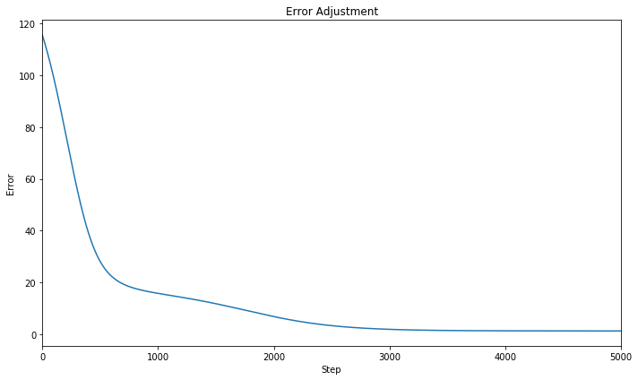

```python
matplotlib.rcParams['figure.figsize'] = (10.0, 6.0)
def matrix_factorization(R, P, Q, K, steps=5000, alpha=0.0002, beta=0.02, plotting_on=True):
    step_error = []
    Q = Q.T
    # we'll do this for the number of steps we have
    for step in xrange(steps):
        # going into the ratings matrix
        for i in xrange(len(R)):
            for j in xrange(len(R[i])):
                # we only want to minimize the difference on nonzero values
                if R[i][j] > 0:
                    # eij is the difference between the true rating and our current PxQ estimate
                    eij = R[i][j] - np.dot(P[i,:], Q[:,j])
                    # now we update based on the gradient. have to do this for every feature
                    for k in xrange(K):
                        P[i][k] = P[i][k] + alpha * (2 * eij * Q[k][j] - beta * P[i][k])
                        Q[k][j] = Q[k][j] + alpha * (2 * eij * P[i][k] - beta * Q[k][j])
        # at this point, we've adjusted for gradient descent for this step
        # now let's see how it does by summing the errors against the actual ratings
        e = 0
        for i in xrange(len(R)):
            for j in xrange(len(R[i])):
                # once again, we only want to compare actual ratings we have
                if R[i][j] > 0:
                    # sum the error
                    e = e + pow(R[i][j] - np.dot(P[i, :], Q[:, j]), 2)
                    # and add the beta term
                    for k in xrange(K):
                        e = e + (beta/2) * (pow(P[i][k], 2) + pow(Q[k][j], 2))
        step_error.append([step, e])
        if e < 0.001:
            break
    if (plotting_on):
        df = pd.DataFrame(step_error, columns=['step', 'error'])
        axes = df.plot(x='step', y='error', kind='line', title='Error Adjustment', legend=False)
        # set the axes and set display
        axes.set_xlabel("Step")
        axes.set_ylabel("Error")
        plt.tight_layout()
    return P, Q.T

nP, nQ = matrix_factorization(ratings_example, P, Q, num_features)
r_hat = np.dot(nP, nQ.T)
print "Original ratings matrix: "
print ratings_example
print "New predicted matrix: "
print r_hat
print "Rounded off...: "
print np.round(r_hat)
```

The `matrix_factorization` method is simply an implementation of the formulas above. I've also plotted the error associated with each step- as you can see, our gradient descent is working since we are always going toward a lower error. Above, I've also printed the original ratings matrix with 0's, the new matrix which is the result of $P \times Q$, and also a rounded version of the new matrix. The rounded version at least matches with all of the nonzero values of the original matrix, so it seems like our factorization function did a reasonable job.

However, that was only a 6x5 matrix, and still took quite a bit of time, due to our many for loops.

```python
# time how long this takes without plotting
print ratings_example.shape
%timeit matrix_factorization(ratings_example, P, Q, num_features, plotting_on=False)

# let's try arbitrarily making the matrix bigger by increasing the number of movies
ratings_example_medium = np.concatenate((ratings_example, ratings_example), axis=1)
print ratings_example_medium.shape
# have to make these bigger too
num_users = len(ratings_example_medium)
num_movies = len(ratings_example_medium[0])
P = np.random.rand(num_users, num_features)
Q = np.random.rand(num_movies, num_features)
%timeit matrix_factorization(ratings_example_medium, P, Q, num_features, plotting_on=False)

# and now let's increase both users and movies
ratings_example_large = np.concatenate((ratings_example_medium, ratings_example_medium), axis=0)
print ratings_example_large.shape
# have to make these bigger too
num_users = len(ratings_example_large)
num_movies = len(ratings_example_large[0])
P = np.random.rand(num_users, num_features)
Q = np.random.rand(num_movies, num_features)
%timeit matrix_factorization(ratings_example_large, P, Q, num_features, plotting_on=False)
```

```
(6, 5)
1 loop, best of 3: 1.85 s per loop
(6, 10)
1 loop, best of 3: 3.54 s per loop
(12, 10)
1 loop, best of 3: 7.17 s per loop
```

We can see that even for a matrix as small as 12x10 the matrix factorization algorithm takes quite a while. It's possible that the time could be cut down if I had a better understanding of numpy functions to optimize Python, but even so, it's clear that matrix factorization takes a while in order to get the error down.

I decided to look into libraries that have already optimized matrix factorization and came across [Graphlab](https://turi.com/). Graphlab is particularly good for large data sets that need efficient distributed and parallel algorithms- sounds perfect for our needs! It also makes model creation very easy and on a high level, similar to what you might see from Microsoft Azure but without the UI.

## Graphlab

### Item Similarity Recommender

Let's redo our item-item similarity recommender using Graphlab.

```python
%%capture
import graphlab as gl
```

```python
# Graphlab uses SFrames instead of Pandas data frames, but the conversion is easy.
# we have training_data as a pandas dframe so...
training_data_gl = gl.SFrame(training_data)

# making a model in graphlab is as easy as...
item_similarity_recommender = gl.item_similarity_recommender.create(training_data_gl, user_id='userId',
                                                                    item_id='movieId', target='rating',
                                                                    similarity_type='cosine')
```

[output not shown]

[output not shown]

[output not shown]

```
    Data has 80003 observations with 671 users and 8397 items.
```

[output not shown]

[output not shown]

[output not shown]

[output not shown]

[output not shown]

[output not shown]

[output not shown]

[output not shown]

[output not shown]

[output not shown]

[output not shown]

[output not shown]

[output not shown]

[output not shown]

[output not shown]

[output not shown]

[output not shown]

[output not shown]

```
Finished training in 1.77718s
```

Nice- training only took a few seconds. Let's make some recommendations now.

```python
movies_data_gl = gl.SFrame(movies_data)

recommendations_two_users = item_similarity_recommender.recommend(users=[1,2], k=5)
recommendations_two_users.head()
```

| userId | movieId | score | rank |
| --- | --- | --- | --- |
| 1 | 1266 | 0.4323049287 | 1 |
| 1 | 2366 | 0.330422970984 | 2 |
| 1 | 1282 | 0.315777940883 | 3 |
| 1 | 2985 | 0.31309926841 | 4 |
| 1 | 919 | 0.292678197225 | 5 |
| 2 | 380 | 0.929120509823 | 1 |
| 2 | 595 | 0.846105656028 | 2 |
| 2 | 165 | 0.827345450719 | 3 |
| 2 | 597 | 0.813455908497 | 4 |
| 2 | 588 | 0.810329466065 | 5 |

[10 rows x 4 columns]

This isn't very informative- let's JOIN these with the movie titles to find out which movies we are talking about.

```python
recs_with_titles = recommendations_two_users.join(movies_data_gl, on='movieId').sort(sort_columns=['userId', 'rank'],
                                                                           ascending=True)
recs_with_titles.head()
```

| userId | movieId | score | rank | title | genres | country |
| --- | --- | --- | --- | --- | --- | --- |
| 1 | 1266 | 0.4323049287 | 1 | Unforgiven (1992) | Drama\|Western | USA |
| 1 | 2366 | 0.330422970984 | 2 | King Kong (1933) | Action\|Adventure\|Fantasy\| Horror ... | USA |
| 1 | 1282 | 0.315777940883 | 3 | Fantasia (1940) | Animation\|Children\|Fantas y\|Musical ... | USA |
| 1 | 2985 | 0.31309926841 | 4 | RoboCop (1987) | Action\|Crime\|Drama\|Sci- Fi\|Thriller ... | USA |
| 1 | 919 | 0.292678197225 | 5 | Wizard of Oz, The (1939) | Adventure\|Children\|Fantas y\|Musical ... | USA |
| 2 | 380 | 0.929120509823 | 1 | True Lies (1994) | Action\|Adventure\|Comedy\|R omance\|Thriller ... | USA |
| 2 | 595 | 0.846105656028 | 2 | Beauty and the Beast (1991) ... | Animation\|Children\|Fantas y\|Musical\|Romance\|IMAX ... | USA |
| 2 | 165 | 0.827345450719 | 3 | Die Hard: With a Vengeance (1995) ... | Action\|Crime\|Thriller | USA |
| 2 | 597 | 0.813455908497 | 4 | Pretty Woman (1990) | Comedy\|Romance | USA |
| 2 | 588 | 0.810329466065 | 5 | Aladdin (1992) | Adventure\|Animation\|Child ren\|Comedy\|Musical ... | USA |

[10 rows x 7 columns]

Instead of only getting 5 recommendations for 2 users, we should get all recommendations for one user in question. If we limited to only 5, it's very unlikely that one of those will be a movie from the country we want.

```python
# get all recs for user
num_movies = ratings_data['movieId'].unique().shape[0]
recommendations = item_similarity_recommender.recommend(users=[2], k=num_movies)
recs_with_titles = recommendations.join(movies_data_gl, on='movieId').sort(sort_columns=['rank'], ascending=True)

# filter for if the country is listed
recommendations_filter_has_country = recs_with_titles[recs_with_titles.apply(lambda x: country in x['country'])]
recommendations_filter_has_country.head(n=5)
```

| userId | movieId | score | rank | title | genres |
| --- | --- | --- | --- | --- | --- |
| 2 | 3260 | 0.0500980168581 | 227 | Howards End (1992) | Drama |
| 2 | 1810 | 0.0400612990061 | 289 | Primary Colors (1998) | Comedy\|Drama |
| 2 | 2364 | 0.0270857264598 | 433 | Godzilla 1985: The Legend Is Reborn (Gojira) ... | Action\|Horror\|Sci- Fi\|Thriller ... |
| 2 | 86982 | 0.0257281661034 | 454 | Destroy All Monsters (Kaijû sôshingeki) ... | Action\|Sci-Fi\|Thriller |
| 2 | 26694 | 0.0257281661034 | 463 | Ju Dou (1990) | Drama |

| country |
| --- |
| UK\|Japan\|USA |
| France\|UK\|Germany\|USA\|Jap an ... |
| Japan |
| Japan |
| China\|Japan |

[5 rows x 7 columns]

```python
# filter for if the country is the only one listed
recommendations_filter_sole_country = recs_with_titles.filter_by(country, 'country')
recommendations_filter_sole_country.head(n=5)
```

| userId | movieId | score | rank | title | genres | country |
| --- | --- | --- | --- | --- | --- | --- |
| 2 | 2364 | 0.0270857264598 | 433 | Godzilla 1985: The Legend Is Reborn (Gojira) ... | Action\|Horror\|Sci- Fi\|Thriller ... | Japan |
| 2 | 86982 | 0.0257281661034 | 454 | Destroy All Monsters (Kaijû sôshingeki) ... | Action\|Sci-Fi\|Thriller | Japan |
| 2 | 44597 | 0.0142295241356 | 980 | Youth of the Beast (Yaju no seishun) (1963) ... | Action\|Crime\|Mystery | Japan |
| 2 | 27741 | 0.0124502629042 | 1054 | Twilight Samurai, The (Tasogare Seibei) (2002) ... | Drama\|Romance | Japan |
| 2 | 65261 | 0.0 | 1318 | Ponyo (Gake no ue no Ponyo) (2008) ... | Adventure\|Animation\|Child ren\|Fantasy ... | Japan |

[5 rows x 7 columns]

The low score is a result of the data set. As we noticed in the graph earlier, there are a lot more movies rated from the US. It is less likely that any given user has seen movies from multiple countries than a user has seen many movies from the USA.

```python
prepared_data_gl = gl.SFrame(prepared_data)
recommendations = item_similarity_recommender.recommend([prepared_data_gl['userId'][0]], k=num_movies, new_observation_data=prepared_data_gl)\
        .join(movies_data_gl, on='movieId').sort(sort_columns=['rank'], ascending=True)
recommendations.filter_by(country, 'country').head()
```

| userId | movieId | score | rank | title | genres | country |
| --- | --- | --- | --- | --- | --- | --- |
| 672 | 86982 | 0.221672798906 | 56 | Destroy All Monsters (Kaijû sôshingeki) ... | Action\|Sci-Fi\|Thriller | Japan |
| 672 | 7564 | 0.142857142857 | 191 | Kwaidan (Kaidan) (1964) | Horror | Japan |
| 672 | 68137 | 0.142857142857 | 192 | Nana (2005) | Drama | Japan |
| 672 | 43899 | 0.142857142857 | 195 | Tony Takitani (2004) | Drama | Japan |
| 672 | 7574 | 0.142857142857 | 196 | Maborosi (Maboroshi no hikari) (1995) ... | Drama | Japan |
| 672 | 71438 | 0.142857142857 | 198 | Still Walking (Aruitemo aruitemo) (2008) ... | Drama | Japan |
| 672 | 103210 | 0.133408464137 | 227 | Fullmetal Alchemist: The Sacred Star of Milos ... | Action\|Adventure\|Animatio n ... | Japan |
| 672 | 26662 | 0.130598090944 | 253 | Kiki's Delivery Service (Majo no takkyûbin) ... | Adventure\|Animation\|Child ren\|Drama\|Fantasy ... | Japan |
| 672 | 27731 | 0.116928895315 | 280 | Cat Returns, The (Neko no ongaeshi) (2002) ... | Adventure\|Animation\|Child ren\|Fantasy ... | Japan |
| 672 | 5971 | 0.11464986347 | 284 | My Neighbor Totoro (Tonari no Totoro) (1 ... | Animation\|Children\|Drama\| Fantasy ... | Japan |

[10 rows x 7 columns]

Interestingly, compared to user 2, my 'score' for Japanese movies is quite a bit higher than any of theirs. Perhaps because I had already rated Howl's Moving Castle before? I actually have seen a few movies from this list before and have to admit that I am a pretty big Totoro fan, as well as Fullmetal Alchemist...

Well, enough speculation- let's see how it does on the test data.

```python
test_data_gl = gl.SFrame(test_data)
print "Training data RMSE: %s" % str(
    item_similarity_recommender.evaluate_rmse(training_data_gl, target='rating')['rmse_overall'])
print "Test data RMSE: %s" % str(
    item_similarity_recommender.evaluate_rmse(test_data_gl, target='rating')['rmse_overall'])
```

```
Training data RMSE: 3.53400138294
Test data RMSE: 3.59276698634
```

That's really close between training and test data! I guess that means I'll have to watch Tony Takitani now...

### Matrix Factorization

```python
matrix_factorization_recommender = gl.ranking_factorization_recommender.create(training_data_gl, user_id='userId', item_id='movieId', target='rating')
```

[output not shown]

[output not shown]

```
    Data has 80003 observations with 671 users and 8397 items.
```

[output not shown]

[output not shown]

```
+--------------------------------+--------------------------------------------------+----------+
```

```
| Parameter                      | Description                                      | Value    |
```

```
+--------------------------------+--------------------------------------------------+----------+
```

```
| num_factors                    | Factor Dimension                                 | 32       |
```

```
| regularization                 | L2 Regularization on Factors                     | 1e-09    |
```

```
| solver                         | Solver used for training                         | adagrad  |
```

```
| linear_regularization          | L2 Regularization on Linear Coefficients         | 1e-09    |
```

```
| ranking_regularization         | Rank-based Regularization Weight                 | 0.25     |
```

```
| max_iterations                 | Maximum Number of Iterations                     | 25       |
```

```
+--------------------------------+--------------------------------------------------+----------+
```

[output not shown]

[output not shown]

[output not shown]

[output not shown]

[output not shown]

[output not shown]

[output not shown]

[output not shown]

[output not shown]

[output not shown]

[output not shown]

[output not shown]

[output not shown]

[output not shown]

[output not shown]

[output not shown]

[output not shown]

[output not shown]

[output not shown]

[output not shown]

[output not shown]

[output not shown]

[output not shown]

[output not shown]

[output not shown]

[output not shown]

[output not shown]

[output not shown]

[output not shown]

[output not shown]

[output not shown]

[output not shown]

[output not shown]

[output not shown]

[output not shown]

[output not shown]

```
       Final objective value: 0.723507
```

```
       Final training RMSE: 0.593907
```

Wow, that only took a bit more than five seconds total. I can't really beat that!

```python
recommendations = matrix_factorization_recommender.recommend([prepared_data_gl['userId'][0]], k=num_movies,
                                                            new_observation_data=prepared_data_gl).join(
    movies_data_gl,on='movieId').sort(sort_columns=['rank'], ascending=True)
recommendations.filter_by(country, 'country').head()
```

| userId | movieId | score | rank | title | genres | country |
| --- | --- | --- | --- | --- | --- | --- |
| 672 | 2019 | 4.22487910308 | 103 | Seven Samurai (Shichinin no samurai) (1954) ... | Action\|Adventure\|Drama | Japan |
| 672 | 3000 | 4.10713948526 | 164 | Princess Mononoke (Mononoke-hime) (1997) ... | Action\|Adventure\|Animatio n\|Drama\|Fantasy ... | Japan |
| 672 | 741 | 4.05105431594 | 203 | Ghost in the Shell (Kôkaku kidôtai) (199 ... | Animation\|Sci-Fi | Japan |
| 672 | 5618 | 4.05064805069 | 204 | Spirited Away (Sen to Chihiro no kamikakushi) ... | Adventure\|Animation\|Fanta sy ... | Japan |
| 672 | 1274 | 3.84490557232 | 415 | Akira (1988) | Action\|Adventure\|Animatio n\|Sci-Fi ... | Japan |
| 672 | 5971 | 3.82190864005 | 445 | My Neighbor Totoro (Tonari no Totoro) (1 ... | Animation\|Children\|Drama\| Fantasy ... | Japan |
| 672 | 6350 | 3.80624006905 | 475 | Laputa: Castle in the Sky (Tenkû no shiro Rapyu ... | Action\|Adventure\|Animatio n\|Children\|Fantasy\|Sc ... | Japan |
| 672 | 5291 | 3.66843757995 | 787 | Rashomon (Rashômon) (1950) ... | Crime\|Drama\|Mystery | Japan |
| 672 | 7022 | 3.64785804071 | 838 | Battle Royale (Batoru rowaiaru) (2000) ... | Action\|Drama\|Horror\|Thril ler ... | Japan |
| 672 | 1537 | 3.644492606 | 850 | Shall We Dance? (Shall We Dansu?) (1996) ... | Comedy\|Drama\|Romance | Japan |

[10 rows x 7 columns]

```python
print "Training data RMSE: %s" % str(
    matrix_factorization_recommender.evaluate_rmse(training_data_gl, target='rating')['rmse_overall'])
print "Test data RMSE: %s" % str(
    matrix_factorization_recommender.evaluate_rmse(test_data_gl, target='rating')['rmse_overall'])
```

```
Training data RMSE: 0.59390681067
Test data RMSE: 1.18867312202
```

Although the test RMSE is higher than the training RMSE, since the output of matrix factorization is the rating itself, it seems like the recommender was able to predict within 1.2 stars of the actual rating for the most part. Neat!

Graphlab even has support for if you want to compare models.

```python
%%capture
results = gl.recommender.util.compare_models(test_data_gl, [item_similarity_recommender, matrix_factorization_recommender], metric='precision_recall')
```

```python
print "Item Similary Precision/Recall:"
results[0]['precision_recall_overall'].head()
```

```
Item Similary Precision/Recall:
```

| cutoff | precision | recall |
| --- | --- | --- |
| 1 | 0.351270553064 | 0.026050191435 |
| 2 | 0.325859491779 | 0.0441307150685 |
| 3 | 0.299451918286 | 0.0572477960275 |
| 4 | 0.281016442451 | 0.068518024056 |
| 5 | 0.273243647235 | 0.082497396332 |
| 6 | 0.260089686099 | 0.0935387884335 |
| 7 | 0.252402306214 | 0.106447469551 |
| 8 | 0.247384155456 | 0.116759146116 |
| 9 | 0.240823783425 | 0.124727794081 |
| 10 | 0.233183856502 | 0.13357468882 |

[10 rows x 3 columns]

```python
print "Matrix Factorization Precision/Recall:"
results[1]['precision_recall_overall'].head()
```

```
Matrix Factorization Precision/Recall:
```

| cutoff | precision | recall |
| --- | --- | --- |
| 1 | 0.203288490284 | 0.0130254969993 |
| 2 | 0.183109118087 | 0.0212294364516 |
| 3 | 0.170403587444 | 0.0286960813807 |
| 4 | 0.162929745889 | 0.0344802561631 |
| 5 | 0.158146487294 | 0.0415651563237 |
| 6 | 0.148978574988 | 0.0446757951739 |
| 7 | 0.144351911168 | 0.0494834795905 |
| 8 | 0.139947683109 | 0.0542567326511 |
| 9 | 0.135691745557 | 0.0590192427306 |
| 10 | 0.131091180867 | 0.0624621711668 |

[10 rows x 3 columns]

It seems like our item similarity recommender did better overall in this case.

## Conclusion

Thanks for reading!